# FROST Overview Jan 2021

JReceveur

2,955,926 sequencing reads remained after quality filtering representing 475 sequence variants. 57 Samples remained after filtering and rarefaction (2,000 reads).

# Import

## Sample Overview

```r
set.seed(3246)
#Parse Silva function
parse_taxonomy_silva_128 <- function(char.vec){
  # Use default to assign names to elements in case problem with greengenes prefix
  char.vec = parse_taxonomy_default(char.vec)
  # Check for unassigned taxa
  if (char.vec["Rank1"] == "Unassigned") {
    char.vec <- c(Rank1="D_0__Unassigned", Rank2="D_1__Unassigned", Rank3="D_2__Unassigned", Rank4="D_3__Unassigned",
                  Rank5="D_4__Unassigned", Rank6="D_5__Unassigned", Rank7="D_6__Unassigned")
  }
  # Define the meaning of each prefix according to SILVA taxonomy
  Tranks = c(D_0="Kingdom", D_1="Phylum", D_2="Class", D_3="Order", D_4="Family", D_5="Genus", D_6="Species")
  # Check for prefix using regexp, warn if there were none. trim indices, ti
  ti = grep("[[:alpha:]]\\_[[:digit:]]{1}\\_\\_", char.vec)
  if( length(ti) == 0L ){
    warning(
      "No silva prefixes were found. \n",
      "Consider using parse_taxonomy_delfault() instead if true for all OTUs. \n",
      "Dummy ranks may be included among taxonomic ranks now."
    )
    # Will want to return without further modifying char.vec
    taxvec = char.vec
    # Replace names of taxvec according to prefix, if any present...
  } else {
    # Format character vectors for Ambiguous taxa
    if( length(ti) < 7 ){
      for (key in names(char.vec)) {
        if ( char.vec[key] == "Ambiguous_taxa" ) {
          tax_no <- (as.numeric(substr(key, 5, 5)) - 1)
          char.vec[key] = sprintf("D_%s__Ambiguous_taxa", tax_no)
        }
      }
      # Reset the trimmed indicies if Ambiguous taxa
      ti = grep("[[:alpha:]]\\_[[:digit:]]{1}\\_\\_", char.vec)
    }
    # Remove prefix using sub-"" regexp, call result taxvec
    taxvec = gsub("[[:alpha:]]\\_[[:digit:]]{1}\\_\\_", "", char.vec)
    # Define the ranks that will be replaced
    repranks = Tranks[substr(char.vec[ti], 1, 3)]
    # Replace, being sure to avoid prefixes notK present in Tranks
    names(taxvec)[ti[!is.na(repranks)]] = repranks[!is.na(repranks)]
  }
  return(taxvec)
}
#Load the packages needed
#To install these packages, run the command install.packages("package name here"), you can also install multiple packages at a time (see R documentation online for more info)
library(vegan)
library(MASS)
library(ggplot2)
library(plyr)
library(dplyr)
library(magrittr)
library(scales)
library(grid)
library(reshape2)
library(phyloseq)
library(randomForest)
library(knitr)
library(ape)
library(ggpubr)
library(viridis)
cbPalette <- c("#999999", "#E69F00", "#56B4E9", "#009E73", "#F0E442", "#0072B2", "#D55E00", "#000000","#CC79A7") #Create a user defined color palette
theme_set(theme_bw(base_size = 18)+theme(panel.grid.major = element_blank(), panel.grid.minor = element_blank()))#Set the general plotting theme see gggplot2 package for more info on other themes
biom=import_biom("FROST2K.biom",parseFunction=parse_taxonomy_silva_128)#Import biom file and use the parse function built above
#If you put the file inside the folder of the R project, you can call it by just typing the file name as in the line above. IF its somewhere else and you need to find the path use the command file.choose() to bring up a browser to find the file path.
#biom
#tax_table(biom)
#tax_table(biom) <- tax_table(biom)[,-c(5:10,14)]#remove dummy ranks #Not needed

metadata=read.table("FROSTMetadata12.22.txt",header = TRUE) #Pull in your metadata and name the R object as metadata
metadata$LocDonor<-paste0(metadata$SampleLoc,":",metadata$Donor_ID) #Create a new field in the metadata by combining the sample loc and donor ID fields
metadata$Time2<-as.character(metadata$Time)#Change the formatting of Time into a character vector rather than numerical
tree=read_tree("FROSTTree.nwk") #Read in the phylogenetic tree of the bacteria that was built in earlier processing


#This next few lines takes the individual files and combines them into a single object to make it easier to work with
sampdat=sample_data(metadata)
sample_names(sampdat)=metadata$SampleID
physeq=merge_phyloseq(biom,sampdat,tree)

physeq=subset_taxa(physeq,Kingdom!="Archaea")
physeq
```

```
## phyloseq-class experiment-level object
## otu_table()   OTU Table:         [ 475 taxa and 57 samples ]
## sample_data() Sample Data:       [ 57 samples by 18 sample variables ]
## tax_table()   Taxonomy Table:    [ 475 taxa by 13 taxonomic ranks ]
## phy_tree()    Phylogenetic Tree: [ 475 tips and 473 internal nodes ]
```

```r
#Currently physeq is the name of the object that combines your biom table (the number of sequences), the metadata and taxonomy
```

## Metadata

```r
metadata
```

```
##    SampleID Sample_ID SampleLoc Time PlacementDay CollectionDate FieldSample_ID
## 1     FR001     1i-mA     Mouth    1    10/8/2018      10/8/2018          1i-mA
## 2     FR002     1i-gA       Gut    1    10/8/2018      10/8/2018          1i-gA
## 3     FR003     1t-mA     Mouth    1    10/8/2018      10/8/2018          1t-mA
## 4     FR004     1t-gA       Gut    1    10/8/2018      10/8/2018          1t-gA
## 5     FR005     2t-mA     Mouth    2    10/8/2018      10/9/2018          2t-mA
## 6     FR006     2t-gA       Gut    2    10/8/2018      10/9/2018          2t-gA
## 7     FR007     3t-mA     Mouth    3    10/8/2018     10/10/2018          3t-mA
## 8     FR008     3t-gA       Gut    3    10/8/2018     10/10/2018          3t-gA
## 9     FR009     4t-mA     Mouth    4    10/8/2018     10/11/2018          4t-mA
## 10    FR010     4t-gA       Gut    4    10/8/2018     10/11/2018          4t-gA
## 11    FR011     5t-mA     Mouth    5    10/8/2018     10/12/2018          5t-mA
## 12    FR012     5t-gA       Gut    5    10/8/2018     10/12/2018          5t-gA
## 13    FR013     6t-mA     Mouth    6    10/8/2018     10/13/2018          6t-mA
## 14    FR014     6t-gA       Gut    6    10/8/2018     10/13/2018          6t-gA
```

[output cut: 229 more lines]

# Alpha Diversity

## Observed Species

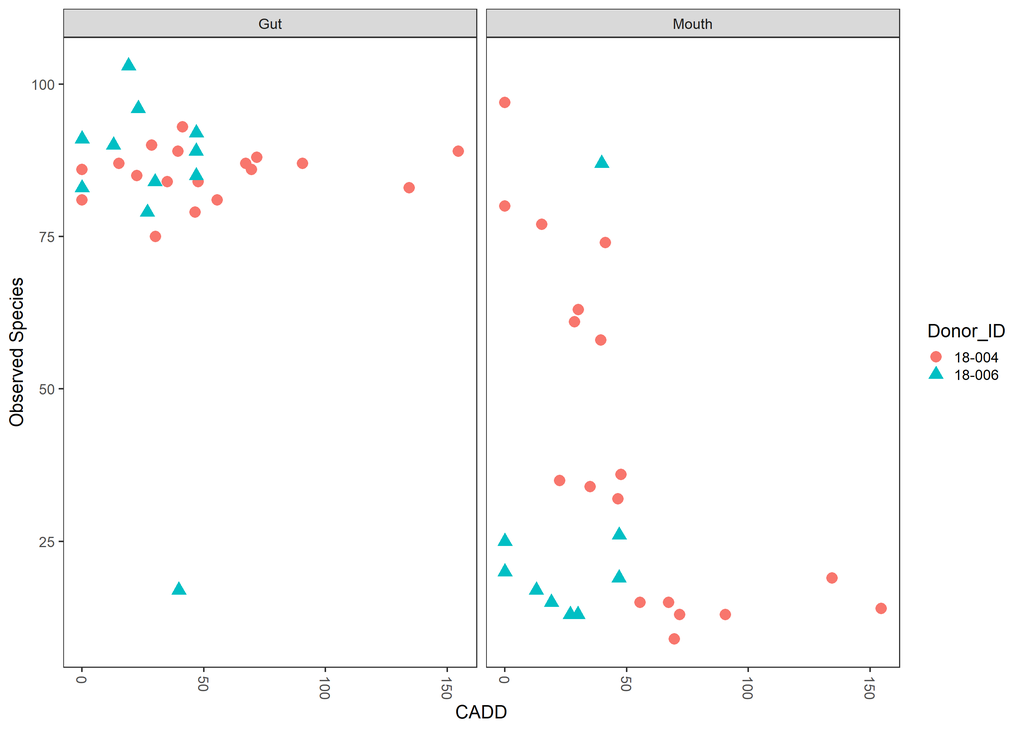

```r
ObservedSpecies<-plot_richness(physeq, x="CADD",color="Donor_ID",shape="Donor_ID", measures=c("Observed"))+ylab("Observed Species")+facet_wrap(~SampleLoc)+geom_point()+scale_fill_manual(cbPalette)+geom_point(size=5)
ObservedSpecies
```

```r
ObservedRichness<-ObservedSpecies$data
head(ObservedRichness)
```

```
##   SampleID Sample_ID SampleLoc Time PlacementDay CollectionDate FieldSample_ID
## 1    FR001     1i-mA     Mouth    1    10/8/2018      10/8/2018          1i-mA
## 2    FR002     1i-gA       Gut    1    10/8/2018      10/8/2018          1i-gA
## 3    FR003     1t-mA     Mouth    1    10/8/2018      10/8/2018          1t-mA
## 4    FR004     1t-gA       Gut    1    10/8/2018      10/8/2018          1t-gA
## 5    FR005     2t-mA     Mouth    2    10/8/2018      10/9/2018          2t-mA
## 6    FR006     2t-gA       Gut    2    10/8/2018      10/9/2018          2t-gA
##    CADD Simplified_ID Donor_ID Date_extracted Extractor Color_of_sample  DNA
## 1  0.00          i-mA   18-004       2/5/2019        RS           white 56.6
## 2  0.00          i-gA   18-004       2/5/2019        RS           brown 24.7
## 3  0.00          1-mA   18-004       2/6/2019        RS           white 49.7
## 4  0.00          1-gA   18-004       2/6/2019        RS  greenish-brown 18.4
## 5 15.06          2-mA   18-004       2/6/2019        RS           white 23.3
## 6 15.06          2-gA   18-004       2/6/2019        RS       tan-brown 32.0
##   X260.280 X260.230     LocDonor Time2 samples variable value se
## 1     1.87     2.04 Mouth:18-004     1   FR001 Observed    80 NA
## 2     1.87     1.44   Gut:18-004     1   FR002 Observed    81 NA
## 3     1.91     2.20 Mouth:18-004     1   FR003 Observed    97 NA
## 4     1.78     0.79   Gut:18-004     1   FR004 Observed    86 NA
## 5     1.86     1.65 Mouth:18-004     2   FR005 Observed    77 NA
## 6     1.86     1.83   Gut:18-004     2   FR006 Observed    87 NA
```

```r
kruskal.test(value~Donor_ID, data=ObservedRichness)
```

```
##
##  Kruskal-Wallis rank sum test
##
## data:  value by Donor_ID
## Kruskal-Wallis chi-squared = 0.0033572, df = 1, p-value = 0.9538
```

```r
ddply(ObservedRichness, c("Donor_ID"), summarise,
                 N    = length(value),
                 mean = mean(value),
                 sd   = sd(value),
                 se   = sd / sqrt(N)
)
```

```
##   Donor_ID  N     mean       sd       se
## 1   18-004 36 63.30556 29.84227 4.973712
## 2   18-006 21 55.38095 36.55609 7.977193
```

```r
GutObs<-subset(ObservedRichness,SampleLoc=="Gut")
MouthObs<-subset(ObservedRichness,SampleLoc=="Mouth")

#head(GutInvSimp)
print("Gut only")
```

```
## [1] "Gut only"
```

```r
kruskal.test(value~Donor_ID, data=GutObs)
```

```
##
##  Kruskal-Wallis rank sum test
##
## data:  value by Donor_ID
## Kruskal-Wallis chi-squared = 0.98213, df = 1, p-value = 0.3217
```

```r
ddply(GutObs, c("Donor_ID"), summarise,
                 N    = length(value),
                 mean = mean(value),
                 sd   = sd(value),
                 se   = sd / sqrt(N)
)
```

```
##   Donor_ID  N     mean        sd       se
## 1   18-004 18 85.22222  4.318981 1.017994
## 2   18-006 11 82.63636 22.747627 6.858668
```

```r
print("Mouth only")
```

```
## [1] "Mouth only"
```

```r
kruskal.test(value~Donor_ID, data=MouthObs)
```

```
##
##  Kruskal-Wallis rank sum test
##
## data:  value by Donor_ID
## Kruskal-Wallis chi-squared = 1.3307, df = 1, p-value = 0.2487
```

```r
ddply(MouthObs, c("Donor_ID"), summarise,
                 N    = length(value),
                 mean = mean(value),
                 sd   = sd(value),
                 se   = sd / sqrt(N)
)
```

```
##   Donor_ID  N     mean       sd       se
## 1   18-004 18 41.38889 28.24294 6.656924
## 2   18-006 10 25.40000 22.09173 6.986018
```

```r
#plot richness is an already built function from the phyloseq package, to get more information about any package you can use the command ?packagename for example typing  (and running) ?phyloseq  will bring up the phyloseq help

#The variables in quotes are the ones from your metadata file or from the function you are running to look at different metadata just change the text in the quotes to another column name from your metadata.
```

## Inverse Simpson

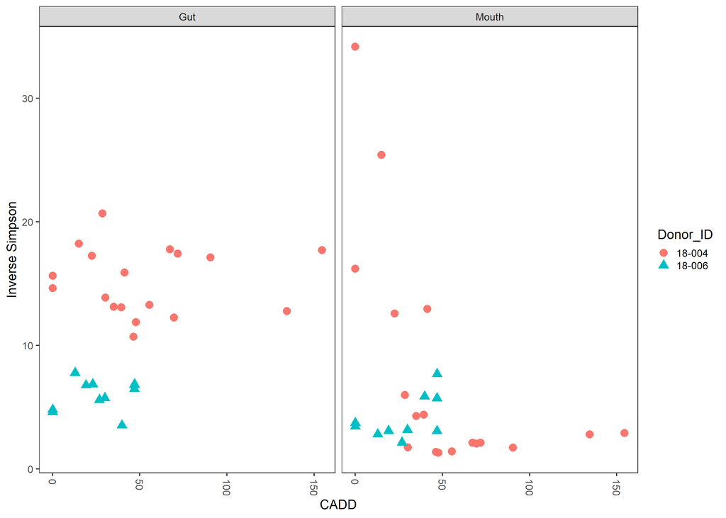

```r
InvSimp<-plot_richness(physeq, x="CADD",color="Donor_ID",shape="Donor_ID", measures=c("InvSimpson"))+ylab("Inverse Simpson")+facet_wrap(~SampleLoc)+geom_point()+scale_fill_manual(cbPalette)+geom_point(size=5)
InvSimp
```

```r
InvSimpData<-InvSimp$data
kruskal.test(value~Donor_ID, data=InvSimpData)
```

```
##
##  Kruskal-Wallis rank sum test
##
## data:  value by Donor_ID
## Kruskal-Wallis chi-squared = 5.2118, df = 1, p-value = 0.02243
```

```r
ddply(InvSimpData, c("Donor_ID"), summarise,
                 N    = length(value),
                 mean = mean(value),
                 sd   = sd(value),
                 se   = sd / sqrt(N)
)
```

```
##   Donor_ID  N      mean       sd        se
## 1   18-004 36 11.349661 7.836519 1.3060865
## 2   18-006 21  5.069117 1.769108 0.3860511
```

```r
GutObs<-subset(InvSimpData,SampleLoc=="Gut")
MouthObs<-subset(InvSimpData,SampleLoc=="Mouth")

#head(GutInvSimp)
print("Gut only")
```

```
## [1] "Gut only"
```

```r
kruskal.test(value~Donor_ID, data=GutObs)
```

```
##
##  Kruskal-Wallis rank sum test
##
## data:  value by Donor_ID
## Kruskal-Wallis chi-squared = 19.8, df = 1, p-value = 8.598e-06
```

```r
ddply(GutObs, c("Donor_ID"), summarise,
                 N    = length(value),
                 mean = mean(value),
                 sd   = sd(value),
                 se   = sd / sqrt(N)
)
```

```
##   Donor_ID  N      mean       sd        se
## 1   18-004 18 15.176179 2.725015 0.6422923
## 2   18-006 11  5.979669 1.256965 0.3789891
```

```r
print("Mouth only")
```

```
## [1] "Mouth only"
```

```r
kruskal.test(value~Donor_ID, data=MouthObs)
```

```
##
##  Kruskal-Wallis rank sum test
##
## data:  value by Donor_ID
## Kruskal-Wallis chi-squared = 0.45057, df = 1, p-value = 0.5021
```

```r
ddply(MouthObs, c("Donor_ID"), summarise,
                 N    = length(value),
                 mean = mean(value),
                 sd   = sd(value),
                 se   = sd / sqrt(N)
)
```

```
##   Donor_ID  N     mean       sd        se
## 1   18-004 18 7.523143 9.380920 2.2111042
## 2   18-006 10 4.067509 1.752552 0.5542055
```

## Shannon Diversity

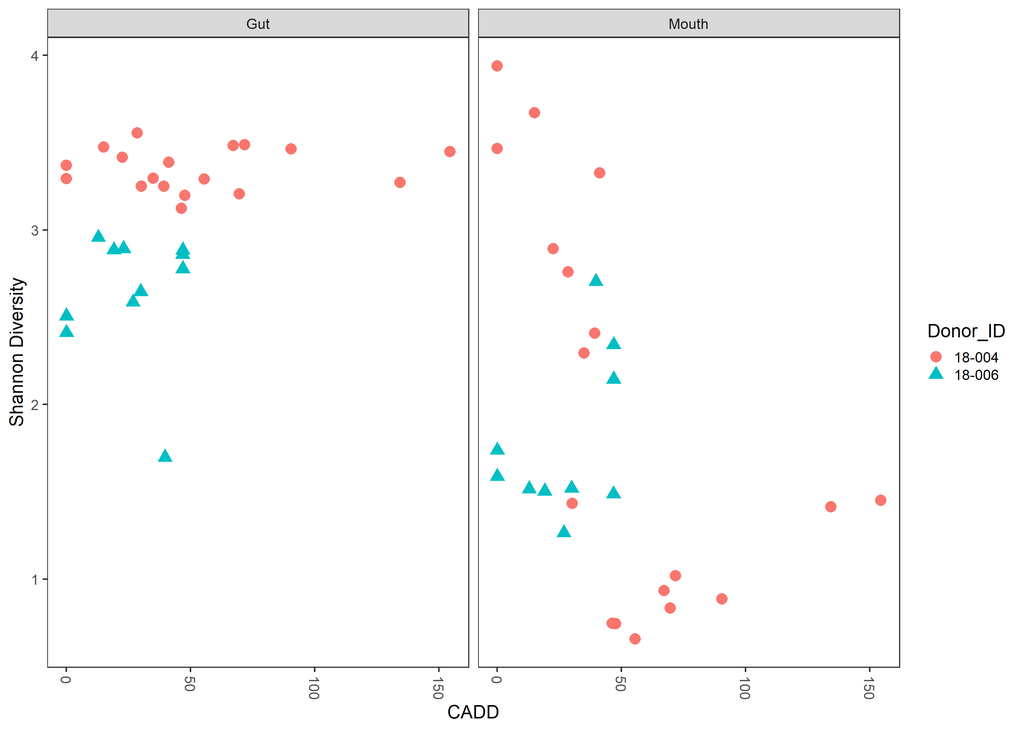

```r
Shannon<-plot_richness(physeq, x="CADD",color="Donor_ID",shape="Donor_ID", measures=c("Shannon"))+ylab("Shannon Diversity")+facet_wrap(~SampleLoc)+geom_point()+scale_fill_manual(cbPalette)+geom_point(size=5)
Shannon
```

```r
ShannonData<-Shannon$data
kruskal.test(value~Donor_ID, data=ShannonData)
```

```
##
##  Kruskal-Wallis rank sum test
##
## data:  value by Donor_ID
## Kruskal-Wallis chi-squared = 5.364, df = 1, p-value = 0.02056
```

```r
ddply(ShannonData, c("Donor_ID"), summarise,
                 N    = length(value),
                 mean = mean(value),
                 sd   = sd(value),
                 se   = sd / sqrt(N)
)
```

```
##   Donor_ID  N     mean       sd        se
## 1   18-004 36 2.642703 1.078937 0.1798228
## 2   18-006 21 2.233899 0.597012 0.1302787
```

```r
GutObs<-subset(ShannonData,SampleLoc=="Gut")
MouthObs<-subset(ShannonData,SampleLoc=="Mouth")

#head(GutInvSimp)
print("Gut only")
```

```
## [1] "Gut only"
```

```r
kruskal.test(value~Donor_ID, data=GutObs)
```

```
##
##  Kruskal-Wallis rank sum test
##
## data:  value by Donor_ID
## Kruskal-Wallis chi-squared = 19.8, df = 1, p-value = 8.598e-06
```

```r
ddply(GutObs, c("Donor_ID"), summarise,
                 N    = length(value),
                 mean = mean(value),
                 sd   = sd(value),
                 se   = sd / sqrt(N)
)
```

```
##   Donor_ID  N     mean        sd         se
## 1   18-004 18 3.347424 0.1220704 0.02877227
## 2   18-006 11 2.645528 0.3618444 0.10910019
```

```r
print("Mouth only")
```

```
## [1] "Mouth only"
```

```r
kruskal.test(value~Donor_ID, data=MouthObs)
```

```
##
##  Kruskal-Wallis rank sum test
##
## data:  value by Donor_ID
## Kruskal-Wallis chi-squared = 0.22989, df = 1, p-value = 0.6316
```

```r
ddply(MouthObs, c("Donor_ID"), summarise,
                 N    = length(value),
                 mean = mean(value),
                 sd   = sd(value),
                 se   = sd / sqrt(N)
)
```

```
##   Donor_ID  N     mean        sd        se
## 1   18-004 18 1.937983 1.1532978 0.2718349
## 2   18-006 10 1.781108 0.4600885 0.1454927
```

# Taxa Plots

*Note: Other taxa (present at an abundance lower than the cutoff, for example 0.1% at the phylum level) make up the remainder of the relative abundance for each sample (100%). While not shown here, will be combined into an other category for any actual manuscript figures.

```r
GPr  = transform_sample_counts(physeq, function(x) x / sum(x) ) #transform samples based on relative abundance
GPrPhylum=tax_glom(GPr, "Phylum")
PhylumLevel = filter_taxa(GPrPhylum, function(x) mean(x) > 1e-3, TRUE) #filter out any taxa lower tha 0.1%
GPrFamily=tax_glom(GPr,"Family")
FamilyLevel = filter_taxa(GPrFamily, function(x) mean(x) > 1e-2, TRUE) #filter out any taxa lower tha 1%
GPrGenus=tax_glom(GPr,"Genus")
GenusLevel = filter_taxa(GPrGenus, function(x) mean(x) > 2e-2, TRUE) #filter out any taxa lower tha 2%
```

## Total Abundances across all samples

Relative Abundances of bacterial phyla

Across all samples, 10 bacterial phyla were identified. Three taxa (Proteobacteria (44.68%), Bacteroidetes (25.76%), and Firmicutes (21.98%) represented 92% of the total bacterial relative abundance across all samples.

At the family level, 64 families were identified with 17 families comprising greater than 1% of the total relative abundance. The three most abundant families were Enterobacteriaceae (20.1% of total abundance), Pseudomonadaceae (18.1%), and Bacteroidaceae (17.1%)

```r
GPr  = transform_sample_counts(physeq, function(x) x / sum(x) ) #transform samples based on relative abundance
PhylumAll=tax_glom(GPr, "Phylum")
PhylumLevel = filter_taxa(PhylumAll, function(x) mean(x) > 1e-3, TRUE) #filter out any taxa lower tha 1%
FamilyAll=tax_glom(GPr,"Family")
FamilyLevel = filter_taxa(FamilyAll, function(x) mean(x) > 1e-2, TRUE) #filter out any taxa lower than 1%
GenusAll=tax_glom(GPr,"Genus")
GenusLevel = filter_taxa(GenusAll, function(x) mean(x) > 1e-2, TRUE) #filter out any taxa lower tha 1%

df <- psmelt(PhylumAll)
df$Abundance=df$Abundance*100
Trtdata <- ddply(df, c("Phylum"), summarise,
                 N    = length(Abundance),
                 mean = mean(Abundance),
                 sd   = sd(Abundance),
                 se   = sd / sqrt(N)
)
#ddply from the ddplyr package is being used here to calculate the mean, standard deviation and standard error of your samples, see below for other examples using it to do the same thing but also between different sample groups
Trtdata
```

```
##                Phylum  N         mean          sd          se
## 1      Actinobacteria 57  2.534215795  3.08517321 0.408641174
## 2       Bacteroidetes 57 25.756847198 19.15430988 2.537050321
## 3  Epsilonbacteraeota 57  0.370175439  0.98261039 0.130149926
## 4          Firmicutes 57 21.984611805 11.91823776 1.578609155
## 5        Fusobacteria 57  2.735964912  4.41016231 0.584140269
## 6        Opisthokonta 57  0.015789474  0.06557295 0.008685350
## 7      Planctomycetes 57  0.001754386  0.01324532 0.001754386
## 8      Proteobacteria 57 44.683974325 27.51714887 3.644735406
## 9        Spirochaetes 57  0.027192982  0.15442005 0.020453435
## 10        Tenericutes 57  0.038596491  0.13693636 0.018137664
## 11         Unassigned 57  0.473684211  1.73055795 0.229218000
## 12    Verrucomicrobia 57  1.376315789  2.33427691 0.309182530
```

```r
print("Family level abundances across all samples (> 1% of total relative abundances")
```

```
## [1] "Family level abundances across all samples (> 1% of total relative abundances"
```

```r
df <- psmelt(FamilyLevel)
df$Abundance=df$Abundance*100
Trtdata <- ddply(df, c("Family"), summarise,
                 N    = length(Abundance),
                 mean = mean(Abundance),
                 sd   = sd(Abundance),
                 se   = sd / sqrt(N)
)
Trtdata
```

```
##                 Family  N      mean        sd        se
## 1      Akkermansiaceae 57  1.374561  2.333321 0.3090559
## 2       Bacteroidaceae 57 17.110221 17.111856 2.2665207
## 3   Enterobacteriaceae 57 20.102370 20.270992 2.6849585
## 4      Enterococcaceae 57  1.021085  1.306630 0.1730674
## 5  Erysipelotrichaceae 57  1.513202  1.446039 0.1915325
## 6            Family XI 57  1.132456  2.106929 0.2790696
## 7     Fusobacteriaceae 57  2.714035  4.352593 0.5765150
## 8      Lachnospiraceae 57  4.325531  4.663135 0.6176473
## 9        Moraxellaceae 57  2.482456  8.199910 1.0861046
## 10       Neisseriaceae 57  2.907895 10.204659 1.3516401
## 11      Prevotellaceae 57  2.947371  7.406611 0.9810295
## 12    Pseudomonadaceae 57 18.063168 28.142047 3.7275051
## 13       Rikenellaceae 57  2.796564  3.111774 0.4121645
## 14     Ruminococcaceae 57  3.553712  4.361314 0.5776701
## 15   Staphylococcaceae 57  2.062281  5.010581 0.6636676
## 16    Streptococcaceae 57  4.811404  6.497321 0.8605912
## 17     Veillonellaceae 57  1.457895  2.182454 0.2890731
```

## Phylum Level

```r
df <- psmelt(PhylumLevel)
df$Abundance=df$Abundance*100
Trtdata <- ddply(df, c("Phylum","SampleLoc","Donor_ID","Time"), summarise,
                 N    = length(Abundance),
                 mean = mean(Abundance)
)
#Trtdata
```

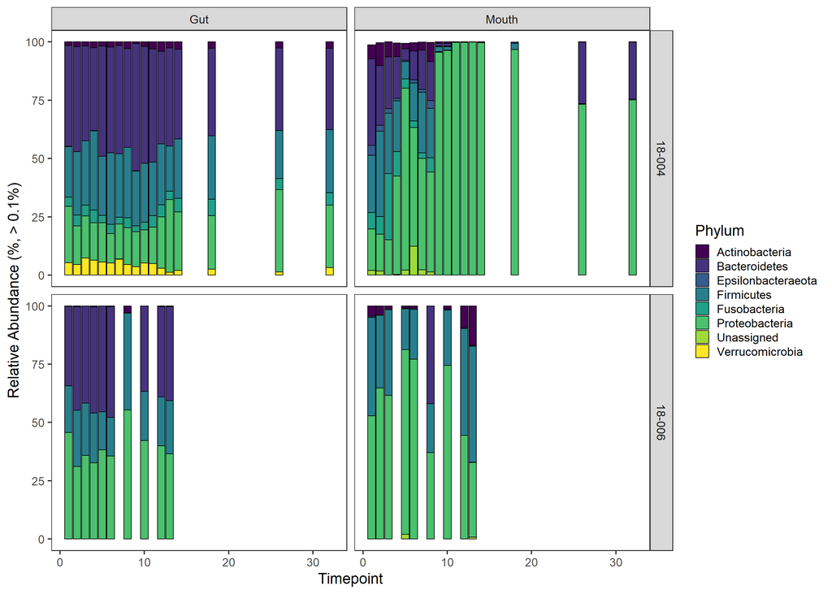

```r
PhylumPlot=ggplot(Trtdata, aes(x=Time,y=mean))+geom_bar(aes(fill = Phylum),colour="black", stat="identity")+
  facet_grid(~Phylum)+xlab("Timepoint")+ylab("Relative Abundance (%, > 0.1%)") + theme(axis.text.x = element_text(angle = 0, hjust = 0.5))+
  facet_grid(Donor_ID~SampleLoc)+scale_fill_viridis_d()
#scale_x_discrete(labels=c("0 hrs", "24 hrs", "48 hrs","72 hrs"))+ theme(axis.text.x = element_text(angle = 45, hjust = 1))#+ scale_fill_manual(values=cbPalette)
PhylumPlot
```

```r
df <- psmelt(PhylumAll)
df$Abundance=df$Abundance*100
Trtdata <- ddply(df, c("Phylum","Donor_ID"), summarise,
                 N    = length(Abundance),
                 mean = mean(Abundance)
)
Donor004<-subset(Trtdata,Donor_ID=="18-004")
Donor004<-subset(Donor004,mean!=0)
Unique004<-unique(Donor004$Phylum)
Donor006<-subset(Trtdata,Donor_ID=="18-006")
Donor006<-subset(Donor006,mean!=0)

Unique006<-unique(Donor006$Phylum)

print("N Phyla unique to 18-004")
```

```
## [1] "N Phyla unique to 18-004"
```

```r
length(subset(Unique004,!(Unique004 %in% Unique006)))
```

```
## [1] 6
```

```r
print("N Phyla unique to 18-006")
```

```
## [1] "N Phyla unique to 18-006"
```

```r
length(subset(Unique006,!(Unique006 %in% Unique004)))
```

```
## [1] 0
```